# ExamineCF.rmd

Rex Macey

January 24, 2016

```r
library(stringr)
library(plyr)
library(lubridate)
library(randomForest)
library(reshape2)
library(formattable)
setwd(Sys.getenv("LENDINGCLUB_DIR"))  # this gets the LENDINGCLUB_DIR variable defined in the .rProfile file
df<-readRDS("LoanStatsAll.rds")
df2<-df # used for all loans
max_issue_d<-max(df$issue_d,na.rm=TRUE)
idx<- (df2$issue_d < (max_issue_d - 3) & df$term == " 36 months") | (df2$issue_d < (max_issue_d - 5) & df$term == " 60 months")
df<-df[idx,]
```

Let’s look at cash flows to make sure we understand them. Here are some of the relevant fields.

```r
amnt_cols<-strsplit("id,funded_amnt,funded_amnt_inv,total_pymnt,total_pymnt_inv,out_prncp,out_prncp_inv,total_rec_late_fee,installment,collection_recovery_fee,recoveries,total_rec_int,total_rec_prncp,loan_status,term,int_rate",split=",")[[1]]
df.cf<-df[,amnt_cols]
head(df.cf[idx,])
```

```
##         id funded_amnt funded_amnt_inv total_pymnt total_pymnt_inv
## 1  1077501        5000            4975    5861.071         5831.78
## 4  1076863       10000           10000   12226.302        12226.30
## 6  1075269        5000            5000    5631.378         5631.38
## 12 1069908       12000           12000   13943.080        13943.08
## 14 1069866        3000            3000    3478.982         3478.98
## 18 1069971        3600            3600    3785.020         3785.02
##    out_prncp out_prncp_inv total_rec_late_fee installment
## 1          0             0               0.00      162.87
## 4          0             0              16.97      339.31
## 6          0             0               0.00      156.46
## 12         0             0               0.00      402.54
## 14         0             0               0.00       96.68
## 18         0             0               0.00      109.57
##    collection_recovery_fee recoveries total_rec_int total_rec_prncp
## 1                        0          0        861.07            5000
## 4                        0          0       2209.33           10000
## 6                        0          0        631.38            5000
## 12                       0          0       1943.08           12000
## 14                       0          0        478.98            3000
## 18                       0          0        185.02            3600
##    loan_status       term int_rate
## 1   Fully Paid  36 months    10.65
## 4   Fully Paid  36 months    13.49
## 6   Fully Paid  36 months     7.90
## 12  Fully Paid  36 months    12.69
## 14  Fully Paid  36 months     9.91
## 18  Fully Paid  36 months     6.03
```

How does funded_amnt differ from funded_amnt_inv? How many are different (#/%)? Let’s look at a few of the loans with differences, especially the larger differences. I think the difference is the amount of the loan funded by LC itself.

```r
summary(df.cf$funded_amnt-df.cf$funded_amnt_inv) # always non-negative
```

```
##    Min. 1st Qu.  Median    Mean 3rd Qu.    Max.
##     0.0     0.0     0.0   466.7    50.0 28920.0
```

```r
idx<-df.cf$funded_amnt>df.cf$funded_amnt_inv
print(paste0(sum(idx)," / ",round(100*sum(idx)/nrow(df.cf),0),"%"))
```

```
## [1] "20877 / 37%"
```

```r
head(df.cf[idx,])
```

```
##          id funded_amnt funded_amnt_inv total_pymnt total_pymnt_inv
## 1   1077501        5000            4975    5861.071         5831.78
## 27  1069800       15000            8725       0.000            0.00
## 52  1068120       25600           25350   29695.623        29405.63
## 122 1068006       19750           19725   11930.650        11915.62
## 157 1064842       12000           11975   14396.580        14366.62
## 206 1067181       12000           11975   13919.414        13890.44
##     out_prncp out_prncp_inv total_rec_late_fee installment
## 1           0             0                  0      162.87
## 27          0             0                  0      514.64
## 52          0             0                  0      824.96
## 122         0             0                  0      643.33
## 157         0             0                  0      411.71
## 206         0             0                  0      386.70
##     collection_recovery_fee recoveries total_rec_int total_rec_prncp
## 1                    0.0000       0.00        861.07         5000.00
## 27                   0.0000       0.00          0.00            0.00
## 52                   0.0000       0.00       4095.62        25600.00
## 122                  6.4129     641.29       2698.78         8590.58
## 157                  0.0000       0.00       2396.58        12000.00
## 206                  0.0000       0.00       1919.41        12000.00
##     loan_status       term int_rate
## 1    Fully Paid  36 months    10.65
## 27  Charged Off  36 months    14.27
## 52   Fully Paid  36 months     9.91
## 122 Charged Off  36 months    10.65
## 157  Fully Paid  36 months    14.27
## 206  Fully Paid  36 months     9.91
```

```r
df.cf.sort<-df.cf[order(-df.cf$funded_amnt+df.cf$funded_amnt_inv),]
head(df.cf.sort,20)
```

```
##             id funded_amnt funded_amnt_inv total_pymnt total_pymnt_inv
## 229014 1100834       35000      6075.00000        0.00            0.00
## 228413 1108831       35000      6325.00000        0.00            0.00
## 42217   178857       25000         0.00000    25207.51            0.00
## 39499   178977       25000        74.98752     7221.69           21.60
## 42113   217413       25000       102.57000    29370.95          119.98
## 39551   184296       25000       274.99199    12982.48          141.65
## 42072   233977       25000       300.00517    19562.82          234.50
## 39599   168222       25000       325.00000    27391.94          355.92
## 39562   180675       25000       450.00443    13650.38          244.97
## 39566   179897       25000       463.66000    30103.55          532.02
## 42228   176633       25000       474.99947    11067.81          210.08
## 39624   157169       25000       499.99940    10361.33          206.15
## 39766   102376       25000       525.00000    29269.66          614.55
## 39554   182845       25000       600.00000    26630.16          639.11
```

[output cut: 90 more lines]

```r
rm(df.cf.sort)
```

Let’s look at total_pymnt v total_pymnt_inv. Note that total_pymnt exceeds total_pymnt_inv more often than funded_amnt exceeds funded_amnt_inv. Perhaps this is because LC may receive some payments that do not go to investors?

```r
summary(df.cf$total_pymnt-df.cf$total_pymnt_inv) # always non-negative
```

```
##     Min.  1st Qu.   Median     Mean  3rd Qu.     Max.
##     0.00     0.00     0.00   474.80    58.05 33440.00
```

```r
idx<-df.cf$total_pymnt>df.cf$total_pymnt_inv
print(paste0(sum(idx)," / ",round(100*sum(idx)/nrow(df.cf),0),"%"))
```

```
## [1] "31209 / 55%"
```

What consistutes total_pymnt? We can see it is total_rec_int+total_rec_prncp+total_rec_late_fee+recoveries

```r
x<-df.cf$total_rec_int+df.cf$total_rec_prncp+df.cf$total_rec_late_fee+df.cf$recoveries
idx<-abs(df.cf$total_pymnt - x) > 0.01
print(paste0(sum(idx)," / ",round(100*sum(idx)/nrow(df.cf),0),"%"))
```

```
## [1] "0 / 0%"
```

What consistutes total_pymnt_inv? Q) Is it a simple proportion related to funded_amnt_inv/funded_amnt A) No, though it does a good job for more than 50% of the loans. Errors on both sides of zero

```r
test<-df.cf$total_pymnt_inv - df.cf$total_pymnt * df.cf$funded_amnt_inv / df.cf$funded_amnt
summary(test)
```

```
##      Min.   1st Qu.    Median      Mean   3rd Qu.      Max.
## -4038.000    -0.004     0.000    -9.184     0.001  2392.000
```

```r
df.cf.sort<-df.cf
df.cf.sort$test<-test
df.cf.sort<-df.cf.sort[order(-df.cf.sort$test),]
head(df.cf.sort)
```

```
##           id funded_amnt funded_amnt_inv total_pymnt total_pymnt_inv
## 40865 459712       25000        19309.42    13446.24        12777.96
## 37228 387672       15000        12723.27    11902.92        11797.68
## 34424 453018       19975        15522.07    13627.92        12097.41
## 33769 463612       12000         9188.63     6453.60         6399.84
## 30704 505253       25000        21153.61    14627.65        13815.06
## 31839 491142       18000        14994.49    10519.95        10166.92
##       out_prncp out_prncp_inv total_rec_late_fee installment
## 40865         0             0            0.00000      840.83
## 37228         0             0            0.00000      527.36
## 34424         0             0            0.00000      681.89
## 33769         0             0            0.00000      403.60
## 30704         0             0            0.00000      822.78
## 31839         0             0           30.79749      617.12
##       collection_recovery_fee recoveries total_rec_int total_rec_prncp
```

[output cut: 20 more lines]

```r
tail(df.cf.sort)
```

```
##           id funded_amnt funded_amnt_inv total_pymnt total_pymnt_inv
## 26557 568459       24000        21100.31    33739.06        26953.20
## 29592 520698       20000        17229.00    11090.36         6752.75
## 29727 519766       25000        22710.29    21055.80        16314.82
## 26350 571768       19000        11516.44    13551.24         5328.06
## 26638 567146       25000        22127.04    20907.57        14663.17
## 27955 544972       15000        11717.38     7671.18         1954.76
##       out_prncp out_prncp_inv total_rec_late_fee installment
## 26557         0             0                0.0      642.96
## 29592         0             0                0.0      438.45
## 29727         0             0                0.0      613.95
## 26350         0             0                0.0      414.25
## 26638         0             0               63.9      638.93
## 27955         0             0                0.0      348.87
##       collection_recovery_fee recoveries total_rec_int total_rec_prncp
## 26557                    0.00       0.00       9739.05        24000.01
## 29592                    0.00       0.00       4081.73         7008.63
## 29727                    8.15     810.86       9107.37        11137.57
## 26350                    0.00       0.00       1218.19        12333.05
## 26638                    8.81     857.66       9949.40        10036.61
## 27955                    0.00       0.00       3335.70         4335.48
##       loan_status       term int_rate      test
## 26557  Fully Paid  60 months    20.53 -2709.499
## 29592 Charged Off  60 months    11.36 -2801.041
## 29727 Charged Off  60 months    16.45 -2812.511
## 26350 Charged Off  60 months    11.12 -2885.734
## 26638 Charged Off  60 months    18.30 -3841.736
## 27955 Charged Off  60 months    13.98 -4037.650
```

Q)Are the loans with unexplained total_pymnt_inv related to loan status? First a summary of the status for all loans, then for those with errors A) All are related to charge offs, but not all charge offs are unexplained

```r
summary(df.cf.sort$loan_status)
```

```
##
##                                                   0
##                                         Charged Off
##                                                6795
##                                             Current
##                                                   0
##                                             Default
##                                                   1
## Does not meet the credit policy. Status:Charged Off
##                                                 698
##     Does not meet the credit policy. Status:Current
##                                                   0
##  Does not meet the credit policy. Status:Fully Paid
##                                                1889
##                                          Fully Paid
##                                               46882
##                                     In Grace Period
##                                                   0
##                                   Late (16-30 days)
##                                                   0
##                                  Late (31-120 days)
##                                                   4
```

```r
idx<-abs(df.cf.sort$test>=1) # not worried about issues less than $1
df.unexp<-df.cf.sort[idx,]
summary(df.unexp$loan_status)
```

```
##
##                                                   0
##                                         Charged Off
##                                                   0
##                                             Current
##                                                   0
##                                             Default
##                                                   0
## Does not meet the credit policy. Status:Charged Off
##                                                 460
##     Does not meet the credit policy. Status:Current
##                                                   0
##  Does not meet the credit policy. Status:Fully Paid
##                                                   0
##                                          Fully Paid
##                                                   0
##                                     In Grace Period
##                                                   0
##                                   Late (16-30 days)
##                                                   0
##                                  Late (31-120 days)
##                                                   0
```

Is the unexplained amount of total_pymnt_inv related to the recovery? Not according to the graph

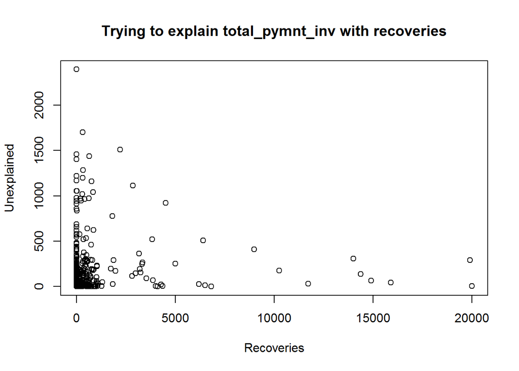

```r
idx<-df.cf.sort$test>=1
plot(df.cf.sort$recoveries[idx],df.cf.sort$test[idx],
     main="Trying to explain total_pymnt_inv with recoveries",xlab="Recoveries",ylab="Unexplained")
```

If we can’t exactly explain total_pymnt_inv, is that a problem? Let’s start with the hypothesis that we investors receive total_pymnt_inv and that someone else receives the rest of total_pymnt. As long as the investors get their fair share, we can focus on total_pymnt and not total_pymnt_inv.

Well sometimes they don’t.

```r
inv_pct<-df.cf$funded_amnt_inv/df.cf$funded_amnt # investors % of the loan
inv_excess<-df.cf$total_pymnt_inv - df.cf$total_pymnt*inv_pct # +/- dollars
summary(inv_excess)
```

```
##      Min.   1st Qu.    Median      Mean   3rd Qu.      Max.
## -4038.000    -0.004     0.000    -9.184     0.001  2392.000
```

Finally, let’s just look at total funded v total payments.

```r
paymentsbystatus <- ddply(df, .(loan_status),summarise,
                      Funded=comma(sum(funded_amnt,na.rm=T),0),
                      Paid=comma(sum(total_pymnt,na.rm=TRUE),0),
                      FundedInv=comma(sum(funded_amnt_inv,na.rm=T),0),
                      PaidInv=comma(sum(total_pymnt_inv,na.rm=TRUE),0),
                      Count=comma(length(funded_amnt),0),
                      FreqPct=percent(length(funded_amnt)/length(df[,1]),1))
print(paymentsbystatus)
```

```
##                                           loan_status      Funded
## 1                                         Charged Off  70,405,350
## 2                                             Default      26,500
## 3 Does not meet the credit policy. Status:Charged Off   6,451,500
## 4  Does not meet the credit policy. Status:Fully Paid  16,233,125
## 5                                          Fully Paid 486,859,425
## 6                                  Late (31-120 days)      34,900
##          Paid   FundedInv     PaidInv  Count FreqPct
## 1  41,487,882  66,289,293  39,394,738  6,795   12.1%
## 2      34,133      26,475      34,101      1    0.0%
## 3   3,309,364   3,878,648   2,032,742    698    1.2%
## 4  19,586,595  11,741,052  14,184,237  1,889    3.4%
## 5 567,688,681 471,779,589 549,745,735 46,882   83.3%
## 6      44,473      34,780      44,341      4    0.0%
```

```r
paymentsbyyear <- ddply(df, .(year_issued),summarise,
                      Funded=comma(sum(funded_amnt,na.rm=T),0),
                      Paid=comma(sum(total_pymnt,na.rm=TRUE),0),
                      FundedInv=comma(sum(funded_amnt_inv,na.rm=T),0),
                      PaidInv=comma(sum(total_pymnt_inv,na.rm=TRUE),0),
                      Count=comma(length(funded_amnt),0),
                      FreqPct=percent(length(funded_amnt)/length(df[,1]),1))
print(paymentsbyyear)
```

```
##   year_issued      Funded        Paid   FundedInv     PaidInv  Count
## 1        2007   4,791,550   4,721,977     799,385     806,209    603
## 2        2008  19,975,025  20,335,021   7,610,187   7,972,459  2,393
## 3        2009  51,814,750  55,922,990  45,777,878  49,526,675  5,281
## 4        2010 104,465,925 115,626,898 101,889,597 112,872,741 10,682
## 5        2011 132,531,100 144,778,525 131,788,482 143,991,736 14,101
## 6        2012 266,432,450 290,765,718 265,884,307 290,266,074 23,209
##   FreqPct
## 1    1.1%
## 2    4.3%
## 3    9.4%
## 4   19.0%
## 5   25.1%
## 6   41.2%
```

```r
paymentsbygrade <- ddply(df, .(grade),summarise,
                      Funded=comma(sum(funded_amnt,na.rm=T),0),
                      Paid=comma(sum(total_pymnt,na.rm=TRUE),0),
                      FundedInv=comma(sum(funded_amnt_inv,na.rm=T),0),
                      PaidInv=comma(sum(total_pymnt_inv,na.rm=TRUE),0),
                      Count=comma(length(funded_amnt),0),
                      FreqPct=percent(length(funded_amnt)/length(df[,1]),1))
print(paymentsbygrade)
```

```
##   grade      Funded        Paid   FundedInv     PaidInv  Count FreqPct
## 1     A 153,384,925 163,778,089 150,719,416 160,910,793 16,462   29.3%
## 2     B 192,646,200 210,310,596 185,847,641 203,279,353 18,650   33.1%
## 3     C 117,677,725 129,433,909 110,796,083 122,405,350 11,642   20.7%
## 4     D  78,171,400  86,740,929  73,501,502  82,069,685  6,659   11.8%
## 5     E  26,615,550  29,746,466  23,682,589  26,774,122  2,011    3.6%
## 6     F   7,622,500   7,932,489   6,152,013   6,608,346    564    1.0%
## 7     G   3,892,500   4,208,650   3,050,592   3,388,243    281    0.5%
```